# Part I - Flights

## Introduction

> This dataset contains U.S. domestic commercial flight records from January 2025, sourced from the Bureau of Transportation Statistics (BTS) On-Time Performance database. Each row in the dataset represents an individual flight, including information about scheduled and actual arrival times, delays, flight distance, and operational characteristics.

> The dataset was limited to a single month to maintain a manageable size while still capturing a large and diverse set of flight records. This allows for meaningful exploration of flight delay patterns without introducing seasonal variation across multiple months.

> The goal of this investigation is to understand general delay patterns using exploratory data visualization, progressing from univariate analysis to bivariate and multivariate relationships.

## Preliminary Wrangling

```python
# import all packages and set plots to be embedded inline
import numpy as np
import pandas as pd
import matplotlib.pyplot as plt
import seaborn as sns
```

```python
flights = pd.read_csv("T_ONTIME_REPORTING.csv")
```

```python
print(flights.shape)
print(flights.dtypes)
print(flights.head(10))
print(flights.tail(10))
```

```
(539747, 19)
YEAR                   int64
FL_DATE               object
OP_UNIQUE_CARRIER     object
ORIGIN                object
DEST                  object
CRS_DEP_TIME           int64
DEP_TIME             float64
DEP_DELAY            float64
DEP_DEL15            float64
ARR_TIME             float64
ARR_DELAY            float64
ARR_DEL15            float64
CANCELLED            float64
DIVERTED             float64
DISTANCE             float64
CARRIER_DELAY        float64
WEATHER_DELAY        float64
NAS_DELAY            float64
SECURITY_DELAY       float64
dtype: object
   YEAR               FL_DATE OP_UNIQUE_CARRIER ORIGIN DEST  CRS_DEP_TIME  \
0  2025  1/1/2025 12:00:00 AM                AA    ABQ  DFW           500
1  2025  1/1/2025 12:00:00 AM                AA    ABQ  DFW           555
2  2025  1/1/2025 12:00:00 AM                AA    ABQ  DFW           820
3  2025  1/1/2025 12:00:00 AM                AA    ABQ  DFW          1032
4  2025  1/1/2025 12:00:00 AM                AA    ABQ  DFW          1700
5  2025  1/1/2025 12:00:00 AM                AA    ABQ  ORD          1343
6  2025  1/1/2025 12:00:00 AM                AA    ALB  CLT           510
7  2025  1/1/2025 12:00:00 AM                AA    ALB  CLT          1134
8  2025  1/1/2025 12:00:00 AM                AA    ALB  CLT          1611
9  2025  1/1/2025 12:00:00 AM                AA    ALB  DFW           537

   DEP_TIME  DEP_DELAY  DEP_DEL15  ARR_TIME  ARR_DELAY  ARR_DEL15  CANCELLED  \
0     452.0       -8.0        0.0     733.0      -21.0        0.0        0.0
1     552.0       -3.0        0.0     832.0      -17.0        0.0        0.0
2     815.0       -5.0        0.0    1052.0      -22.0        0.0        0.0
3    1029.0       -3.0        0.0    1300.0      -23.0        0.0        0.0
4    1707.0        7.0        0.0    2005.0       17.0        1.0        0.0
5    1350.0        7.0        0.0    1723.0      -13.0        0.0        0.0
```

[output cut: 48 more lines]

```
539744        0.0        0.0       0.0    1147.0            NaN
539745        0.0        0.0       0.0    1147.0            NaN
539746        0.0        0.0       0.0     522.0            NaN

        WEATHER_DELAY  NAS_DELAY  SECURITY_DELAY
539737            0.0        8.0             0.0
539738            NaN        NaN             NaN
539739            NaN        NaN             NaN
539740            0.0        0.0             0.0
539741            NaN        NaN             NaN
539742            NaN        NaN             NaN
539743            NaN        NaN             NaN
539744            NaN        NaN             NaN
539745            NaN        NaN             NaN
539746            NaN        NaN             NaN
```

```python
flights.info()
```

```
<class 'pandas.core.frame.DataFrame'>
RangeIndex: 539747 entries, 0 to 539746
Data columns (total 19 columns):
 #   Column             Non-Null Count   Dtype
---  ------             --------------   -----
 0   YEAR               539747 non-null  int64
 1   FL_DATE            539747 non-null  object
 2   OP_UNIQUE_CARRIER  539747 non-null  object
 3   ORIGIN             539747 non-null  object
 4   DEST               539747 non-null  object
 5   CRS_DEP_TIME       539747 non-null  int64
 6   DEP_TIME           523861 non-null  float64
 7   DEP_DELAY          523824 non-null  float64
 8   DEP_DEL15          523824 non-null  float64
 9   ARR_TIME           523167 non-null  float64
 10  ARR_DELAY          522269 non-null  float64
 11  ARR_DEL15          522269 non-null  float64
 12  CANCELLED          539747 non-null  float64
 13  DIVERTED           539747 non-null  float64
 14  DISTANCE           539747 non-null  float64
 15  CARRIER_DELAY      98130 non-null   float64
 16  WEATHER_DELAY      98130 non-null   float64
 17  NAS_DELAY          98130 non-null   float64
 18  SECURITY_DELAY     98130 non-null   float64
dtypes: float64(13), int64(2), object(4)
memory usage: 78.2+ MB
```

### What is the structure of your dataset?

> The dataset consists of individual U.S. commercial flight records from January 2025, where each row represents a single flight. The dataset contains several hundred thousand observations and includes both numerical and categorical variables. Numerical variables include arrival and departure delays, flight distance, and scheduled times, while categorical variables include airline, origin airport, and destination airport.

### What is/are the main feature(s) of interest in your dataset?

> The primary feature of interest in this dataset is arrival delay, which measures how late or early a flight arrives relative to its scheduled arrival time. Arrival delay is a key indicator of flight performance and passenger experience, making it a meaningful outcome variable for this analysis.

## Univariate Exploratio

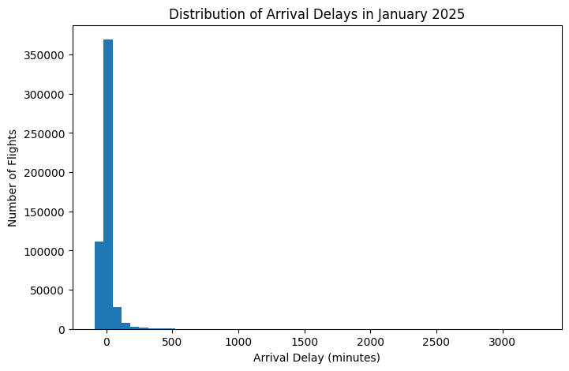

```python
# Remove missing arrival delays
delay = flights[flights['ARR_DELAY'].notna()]

# Create histogram
plt.figure(figsize=(8, 5))
plt.hist(delay['ARR_DELAY'], bins=50)
plt.xlabel('Arrival Delay (minutes)')
plt.ylabel('Number of Flights')
plt.title('Distribution of Arrival Delays in January 2025')
plt.show()
```

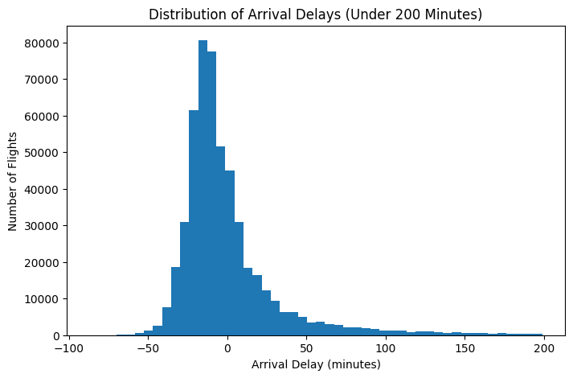

```python
plt.figure(figsize=(8, 5))
plt.hist(delay[delay['ARR_DELAY'] < 200]['ARR_DELAY'], bins=50)
plt.xlabel('Arrival Delay (minutes)')
plt.ylabel('Number of Flights')
plt.title('Distribution of Arrival Delays (Under 200 Minutes)')
plt.show()
```

### Discuss the distribution(s) of your variable(s) of interest. Were there any unusual points? Did you need to perform any transformations?

> The distribution of arrival delays is heavily right-skewed, with most flights arriving close to their scheduled arrival time or slightly early. A smaller number of flights experience large positive delays, creating a long right tail in the distribution. This indicates that while severe delays are relatively rare, they can significantly impact overall flight performance.

### Of the features you investigated, were there any unusual distributions? Did you perform any operations on the data to tidy, adjust, or change the form of the data? If so, why did you do this?

> For clarity, extreme delays above 200 minutes were excluded from this view.

## Bivariate Exploration

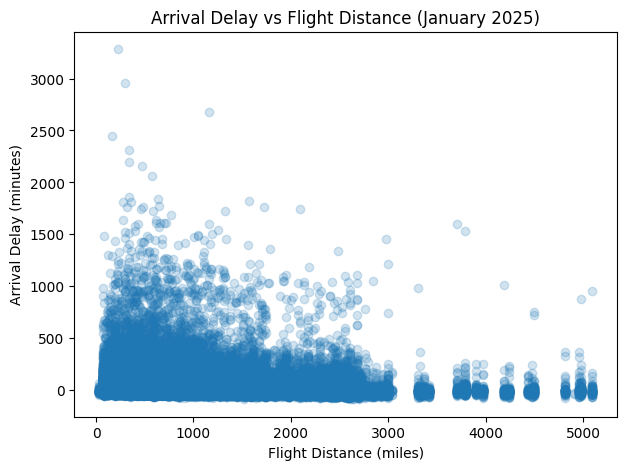

```python
plt.figure(figsize=(7, 5))
plt.scatter(delay['DISTANCE'], delay['ARR_DELAY'], alpha=0.2)
plt.xlabel('Flight Distance (miles)')
plt.ylabel('Arrival Delay (minutes)')
plt.title('Arrival Delay vs Flight Distance (January 2025)')
plt.show()
```

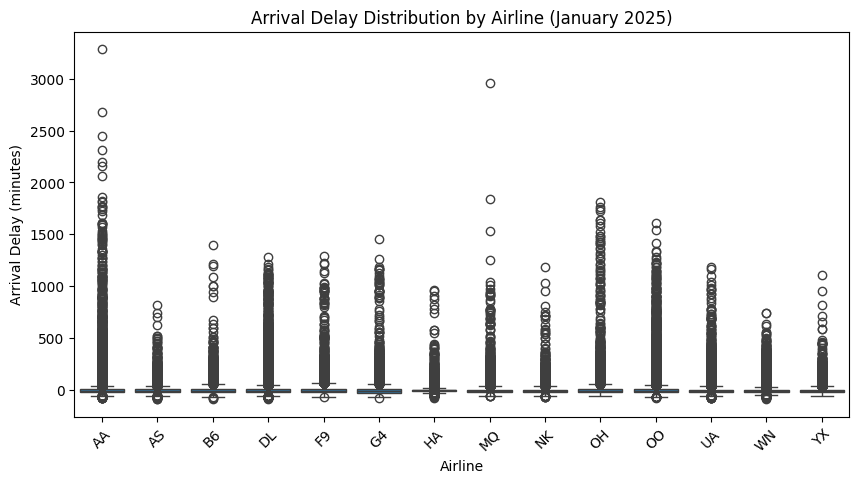

```python
plt.figure(figsize=(10, 5))
sns.boxplot(data=delay, x='OP_UNIQUE_CARRIER', y='ARR_DELAY')
plt.xlabel('Airline')
plt.ylabel('Arrival Delay (minutes)')
plt.title('Arrival Delay Distribution by Airline (January 2025)')
plt.xticks(rotation=45)
plt.show()
```

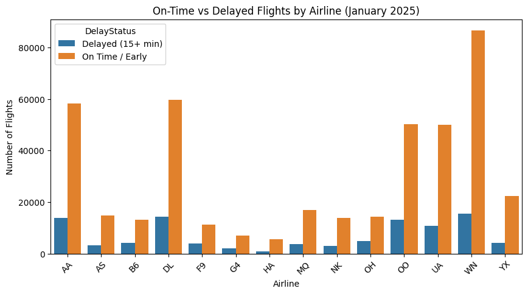

```python
delay = flights[flights['ARR_DEL15'].notna()].copy()

delay['DelayStatus'] = delay['ARR_DEL15'].map({
    0: 'On Time / Early',
    1: 'Delayed (15+ min)'
})

# Create count table
delay_counts = (
    delay
    .groupby(['OP_UNIQUE_CARRIER', 'DelayStatus'])
    .size()
    .reset_index(name='Count')
)

plt.figure(figsize=(10, 5))
sns.barplot(
    data=delay_counts,
    x='OP_UNIQUE_CARRIER',
    y='Count',
    hue='DelayStatus'
)
plt.xlabel('Airline')
plt.ylabel('Number of Flights')
plt.title('On-Time vs Delayed Flights by Airline (January 2025)')
plt.xticks(rotation=45)
plt.show()
```

### Talk about some of the relationships you observed in this part of the investigation. How did the feature(s) of interest vary with other features in the dataset?

> Several relationships between arrival delay and other features were observed during the bivariate exploration. Arrival delays varied noticeably across airlines, with some carriers showing wider delay distributions and more extreme outliers than others, although median delays for most airlines remained close to zero. The relationship between flight distance and arrival delay appeared weak, as both short- and long-distance flights experienced a wide range of delays. Additionally, the proportion of delayed flights differed across airlines, suggesting that operational performance varies by carrier.

### Did you observe any interesting relationships between the other features (not the main feature(s) of interest)?

> Beyond the main feature of interest, differences were also observed in how airlines contribute to overall flight volume and delay frequency. Some airlines operated a significantly larger number of flights during the month, which influenced the absolute number of delays observed. Additionally, variability in delay outcomes across airlines suggests differences in operational consistency that are not solely explained by arrival delay values alone.

## Multivariate Exploration

```python
# Ensure CRSDepTime is numeric
delay = delay[delay['CRS_DEP_TIME'].notna()].copy()

# Convert HHMM to hour
delay['DepHour'] = (delay['CRS_DEP_TIME'] // 100).astype(int)
```

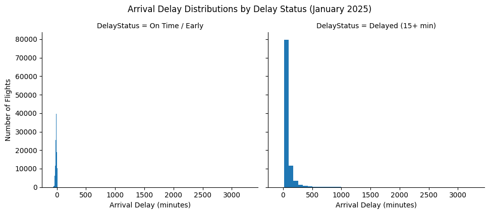

```python
g = sns.FacetGrid(
    delay,
    col='DelayStatus',
    height=4,
    aspect=1.2,
    sharex=True,
    sharey=True
)

g.map(plt.hist, 'ARR_DELAY', bins=40)
g.set_axis_labels('Arrival Delay (minutes)', 'Number of Flights')
g.fig.suptitle(
    'Arrival Delay Distributions by Delay Status (January 2025)',
    y=1.05
)
plt.show()
```

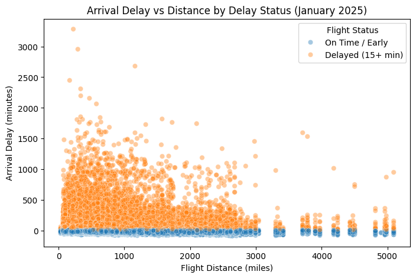

```python
plt.figure(figsize=(8, 5))
sns.scatterplot(
    data=delay,
    x='DISTANCE',
    y='ARR_DELAY',
    hue='DelayStatus',
    alpha=0.4
)

plt.xlabel('Flight Distance (miles)')
plt.ylabel('Arrival Delay (minutes)')
plt.title('Arrival Delay vs Distance by Delay Status (January 2025)')
plt.legend(title='Flight Status')
plt.show()
```

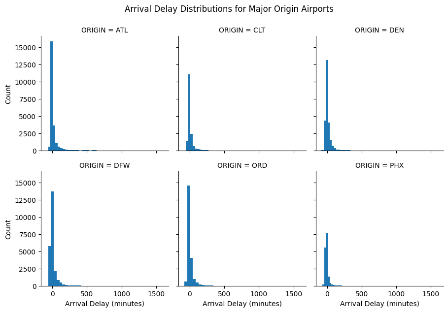

```python
top_origins = delay['ORIGIN'].value_counts().head(6).index
top = delay[delay['ORIGIN'].isin(top_origins)]

g = sns.FacetGrid(
    top,
    col='ORIGIN',
    col_wrap=3,
    height=3,
    sharex=True,
    sharey=True
)
g.map(plt.hist, 'ARR_DELAY', bins=40)
g.set_axis_labels('Arrival Delay (minutes)', 'Count')
g.fig.suptitle(
    'Arrival Delay Distributions for Major Origin Airports',
    y=1.05
)
plt.show()
```

### Talk about some of the relationships you observed in this part of the investigation. Were there features that strengthened each other in terms of looking at your feature(s) of interest?

> Multivariate analysis showed that delay status strongly reinforced arrival delay patterns, with severe delays concentrated among delayed flights across all distances. While flight distance alone did not explain arrival delay, examining it alongside delay status highlighted how delays vary in severity rather than occurrence. Overall, interactions between features suggested that arrival delays result from multiple contributing factors rather than a single explanatory variable.

## Conclusions

> This investigation explored U.S. flight performance in January 2025 with a focus on arrival delays. Initial univariate analysis showed that most flights arrived on time or slightly early, while a smaller proportion experienced substantial delays, resulting in a right-skewed delay distribution. This established arrival delay as a meaningful feature for further analysis.

> Bivariate and multivariate explorations revealed that arrival delays varied across operational contexts. Delay severity differed by categorical groupings such as delay status and origin-related characteristics, while flight distance showed little direct relationship with arrival delay magnitude. Scatter plots and box plots highlighted that both short- and long-distance flights can experience significant delays, indicating that distance alone is not a strong predictor of arrival performance.

> Multivariate analysis strengthened these findings by examining how multiple features interact. When delay status was considered alongside arrival delay and flight distance, severe delays were shown to be concentrated within delayed flights across all distances. These interactions suggest that arrival delays are influenced by multiple contributing factors rather than any single explanatory variable.

> Overall, the step-by-step exploratory approach—from univariate to multivariate analysis—helped uncover patterns, validate earlier observations, and avoid premature conclusions. While this analysis was limited to a single month of data, it provided valuable insight into flight delay behavior and demonstrated how thoughtful visualization supports effective data-driven investigation.